# [WUR Geoscripting](https://geoscripting-wur.github.io/)

# Extra: Geoscripting in R: demos

This page is intended as a demonstration of geoscripting potential. This is done by providing geo-spatial showcases (e.g. data manipulation, visualization, analysis). Every showcase is followed by:

- A reflection of what is the interest of using scripting for that particular problem.
- An assessment of the R knowledge required to perform that particular problem.

**Note that most of the examples given here are using packages that are now deprecated.** They are remains from old tutorials and exercises from this course in the past. Nonetheless, they are still useful for demonstration and inspiration!

# Demo 1: Integrated analysis chain from download to analysis

In the script below we do the following:

- Download SRTM data for a country e.g. Belgium.
- Randomly sample height data.
- Visualise results

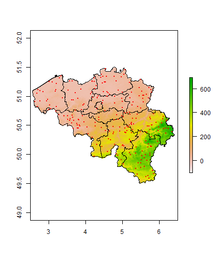

```r
# Load libraries
library(raster)
library(spatstat)
library(rgeos)

# You can choose your own country here
bel <- raster::getData('alt', country = 'BEL', mask = TRUE) # SRTM 90m height data
belshp <- raster::getData('GADM', country = 'BEL', level = 2) # administrative boundaries

# Create random points
dran <- runifpoint(500, win = as.vector(extent(bel)))

# Make the random point spatial points
S <- SpatialPoints(data.frame(x = dran$x, y = dran$y),
                   proj4string = CRS(proj4string(belshp)))

# Select only the ones within belgium
Sint <- gIntersection(S, belshp)

# Create a map
plot(bel)
plot(belshp, add = TRUE)
plot(
  Sint,
  add = TRUE,
  col = "red",
  pch = 19,
  cex = 0.2
)
```

Now we can sample the height data, and plot following random point id:

```r
out <- extract(bel, Sint, df = TRUE)
colnames(out) <- c("id", "height")
head(out)
```

```r
##   id height
## 1  1      8
## 2  2      0
## 3  3     31
## 4  4      0
## 5  5      0
## 6  6     10
```

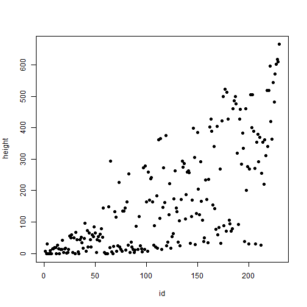

```r
plot(out, type = "p", pch = 19)
```

This example can easily be run for every country of the world with minimal human intervention, and therefore also constitute an other case of automation.

## The contribution of scripting

- Ability to automatically download data from any place in the world.
- Quick and efficient analysis by sampling data randomly.
- Can easiliy be repeated for other countries, other datasets (reproducible).
- Fully integrated analysis chain, from data download to output.

## Basic scripting skills required

- String handling (generate automatic file names, recognize patterns, etc …).
- Querying lists and data.frames.
- Error handling.
- Handling raster and vector data.
- Understanding and using basic spatial analysis functions.

# Demo 2: Visualize the temporal profile of a pixel

The example below illustrates how a small function allows to quickly visualize temporal profile of a raster time-series.

```r
# Download a spatio-temporal dataset
download.file(url = 'https://raw.githubusercontent.com/loicdtx/bfastSpatial/master/data/tura.rda', destfile = 'tura.rda', method = 'auto')
load('tura.rda')
```

There is now a variable named `tura` in your environment, it is a time-series of NDVI over an area of Ethiopia.

```r
library(zoo)

# Define the function to extract and plot the time series
click2ts <- function(x) {
  val <- click(x, n = 1)
  z <- getZ(x)
  plot(
    zoo(t(val), z),
    type = 'p',
    pch = 20,
    xlab = 'Time',
    ylab = 'NDVI (-)'
  )
}
```

Then run the code block below. R will be waiting for you to click on the map, and quickly after the time-series will appear.

```r
plot(tura, 1)
click2ts(tura)
```

## The contribution of scripting

- Exploring the temporal dimension of a dataset is often not possible in classical GIS environments. The flexibility of scripting allows to do that with minimal efforts.

## Basic scripting skills required

- Understanding the structure of spatial objects.
- Writing functions.

# Demo 3: Implement a custom made function to a raster time-series

The example below uses a time-series of MODIS VCF data, which corresponds to percentage tree cover, to investigate temporal trends of tree cover over the Netherlands.

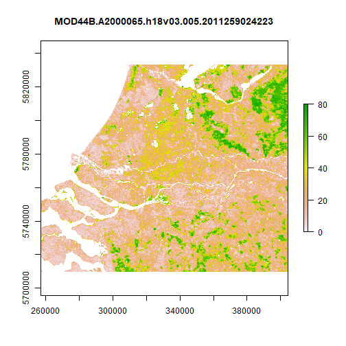

```r
# Load libraries
library(zoo)
library(lubridate)
library(raster)

# Download data (if it doesn't work, try with method='wget')
download.file(url = 'https://raw.githubusercontent.com/GeoScripting-WUR/Scripting4Geo/gh-pages/data/MODIS_VCF_2000-2010_NL.rds',
              destfile = 'MODIS_VCF_2000-2010_NL.rds',
              method = 'auto')

# Read the data
modis <- readRDS('MODIS_VCF_2000-2010_NL.rds')

# Clean data (values > 100 correspond to water)
modis[modis > 100] <- NA

# Visualize
plot(modis, 1)
```

```r
# For the example we will reduce the extent so that processing does not take too long
e <- extent(340101, 370323, 5756221, 5787772)
plot(e, add = TRUE)
modis_sub <- crop(modis, e)
plot(modis_sub, 1)

# Define function to calculate temporal trends
fun <- function(x) {
  ts <- zoo(x, time)
  df <- data.frame(t = decimal_date(index(ts)), vcf = c(ts))
  out <- try(lm(vcf ~ t, data = df)$coefficients[2], silent = T)
  if (class(out) == 'try-error')
    out <- NA
  return(out)
}

# Run the function spatially
time <- getZ(modis)
out <- calc(x = modis_sub, fun = fun)

# Visualize output
plot(out)
hist(out, main = 'Tree cover change at 250 m resolution (2000-2010)', xlab = 'Percentage change')
```

[output not shown]

You should see a map displaying the tree cover percentage temporal trends for the 2000-2010 period.

## Contribution of scripting

- Scripting, thanks to its flexibility, offers the possibility to implement any custom made function to any dataset.

## Basic scripting skills required

- Writing functions.
- Manipulating spatial objects.
- Knowing the details of the functions/algorithms to be implemented spatially.

# Demo 4: Interactive maps

Check out the nice new leaflet package for R, that creates interactive web maps with the JavaScript ‘Leaflet’ Library.

```r
library(leaflet)
m <- leaflet()
m <- addTiles(m)
m <- addMarkers(m, lng = 5.665349, lat = 51.987870, popup = "Wageningen University")
m
```

See here for the result of the above code: [Wageningen Leaflet Demo](https://geoscripting-wur.github.io/Scripting4Geo/leaflet.html)

For more information: http://www.htmlwidgets.org/showcase_leaflet.html

Advanced examples are possible, as shown [here](https://gallery.shinyapps.io/063-superzip-example), with an integration of shiny and [leaflet](http://leafletjs.com/). (Example provided by [RStudio](http://shiny.rstudio.com/gallery/))

## Contribution of scripting

- “User friendly” interface to JavaScript libraries.

## Basic scipting skills required

- Dataframe manipulation.
- String manipulation (subsetting, pattern matching).
- Function writing.

# Reproducibility

Note that all examples shown in this demo have at least one characteristic in common; they are all **reproducible**. While you may not always remember the parameters you have selected when analyzing or creating map in a GIS environment, scripting leaves a fully reproducible mark of what you have done.

# Summary

Geoscripting allows us to:

- Automate steps and deal with large amounts of data.
- Solve complex problems (run custom made functions, while traditional GIS environments are limited to the features they provide).
- Make work reproducible (also beneficial for collaboration).
- Visualize data and build interactive geo-data visualization tools.

# Inspiration and more info

- [Using Jupyter notebook within OSGEO](http://www.r-bloggers.com/interactive-r-notebooks-with-jupyter-and-sagemathcloud/)
- [Interactive reports in R with knitr](http://www.magesblog.com/2012/05/interactive-reports-in-r-with-knitr-and.html)
- [How to clip polygons using polygons](https://gis.stackexchange.com/questions/93096/how-to-perform-a-true-gis-clip-of-polygons-layer-using-a-polygon-layer-in-r)
- [Yet another tutorial](https://pakillo.github.io/R-GIS-tutorial/)
- [googleVis package](http://github.com/mages/googleVis)

Styled with knitrBootstrap